# Predicting Top 10 Billboard Hits Using Audio Features and Metadata

Author

Nitpreet Bamra, Eshadhi Bogoda, Jack Liu, James Wang

Published

November 18, 2026

```python
import pandas as pd
import numpy as np
import altair as alt
alt.data_transformers.disable_max_rows()
import kagglehub
from kagglehub import KaggleDatasetAdapter
import zipfile
from sklearn.model_selection import train_test_split, StratifiedKFold, cross_val_score
from sklearn.preprocessing import OneHotEncoder, StandardScaler
from sklearn.compose import ColumnTransformer
from sklearn.pipeline import Pipeline
from sklearn.linear_model import LogisticRegression
from sklearn.multiclass import OneVsRestClassifier
from sklearn.metrics import (confusion_matrix, ConfusionMatrixDisplay, classification_report)
from pathlib import Path
from sklearn.compose import make_column_transformer
from sklearn.pipeline import make_pipeline
from sklearn.impute import SimpleImputer
import ast
from sklearn.dummy import DummyClassifier
from sklearn.model_selection import cross_validate
from sklearn.model_selection import GridSearchCV
import matplotlib.pyplot as plt
from sklearn.metrics import accuracy_score, precision_score, recall_score, f1_score
```

## Summary

This project investigates whether a song’s audio features, genre, and release era can predict whether a Billboard Hot 100 song reaches the Top 10. Using historical Billboard chart data and Spotify audio features obtained from Kaggle, we developed a logistic regression classification model and compared its performance against a baseline model. Our tuned logistic regression model achieved an accuracy of 58.6%, recall of 65.0%, precision of 16.9%, and F1-score of 0.268 on the held-out test set. Although the model correctly identified approximately 65% of Top 10 songs, its low precision indicates that many songs predicted to reach the Top 10 did not actually do so. However, the baseline model achieved a higher accuracy of 88.3% but failed to identify any Top 10 songs. These findings suggest that audio features, genre, and release era provide limited predictive information about chart success. The imbalance between Top 10 and non-Top 10 songs, along with the model’s high number of false positives, are important limitations. Overall, the model is not yet reliable enough for predicting Top 10 chart success in practice.

## Introduction

The Billboard Hot 100 is the main weekly ranking of the most popular songs in the United States. Songs are ranked using a combination of streaming, radio airplay and digital sales. Reaching the Top 10 of this chart is a major marker of commercial success. A Top 10 song typically brings an artist wider recognition, more radio play and greater visibility on streaming platforms.

Predicting which songs will become hits is valuable to many people in the music industry. If the way a song sounds can help predict its success, record labels and streaming services could make more informed decisions about where to invest their time and money. Additionally, this information could help new artists break into the music industry.

Spotify audio features, which describe characteristics of a song such as its danceability, energy and tempo, are widely used in music research, for example in predicting Spotify audio features from Last.fm tags (Castillo, Flores, and Leray 2024). Our research question is: can a song’s audio features, genre and release era predict whether it reaches the Top 10?

To answer this question, we use the “Billboard Hot Weekly Charts” dataset from Kaggle (The Devastator 2023) originally compiled by Sean Miller (Miller 2023). It combines the weekly Billboard Hot 100 charts since 1958 with audio features for each song from Spotify’s Web API, such as danceability, energy, valence (how positive a song sounds) and tempo, as well as each song’s genre. After cleaning, each row in our data represents one song, with 24,074 songs in total. Our target variable is whether a song reached the Top 10: a song is classified as “Top 10” if its peak position on the Hot 100 was 10 or lower (that is, it reached the Top 10 at least once), and “Not Top 10” otherwise. Because every song in the data has a known peak position along with its audio features and genre, this data allows us to directly test whether these characteristics can predict Top 10 success.

## Methods

### Data

We use the “Billboard Hot Weekly Charts” dataset on Kaggle (The Devastator 2023), which was originally compiled by Sean Miller (Miller 2023). It has two files:

- **Hot Stuff** records each song’s position on the Billboard Hot 100 for every week since 1958.
- **Hot 100 Audio Features** records Spotify audio features and genre for songs on the chart.

The download code below fetches both files with the `kagglehub` package and saves them to `data/raw/`. We join the files on song title and performer, keeping songs found in both. Each song is kept once, using the week it reached its peak position. We then drop unused columns and rows with missing values, and save the result to `data/processed/`.

After cleaning, each row is one song, and the data has 24,074 songs. The target is whether a song reached the Top 10: a song is “Top 10” if its peak position was 10 or lower, and “Not Top 10” otherwise. The predictors are:

- audio features: danceability, energy, valence, loudness, tempo, acousticness, speechiness, instrumentalness, liveness and track duration;
- release era: the year of the song’s peak week;
- primary genre: the first genre listed for the song;
- explicit content: whether the track is marked explicit.

```python
## Data Download
dataset = "thedevastator/billboard-hot-100-audio-features"
files = ["Hot Stuff.csv", "Hot 100 Audio Features.csv"]

for name in files:
    downloaded = kagglehub.dataset_download(dataset, name)
    with open(downloaded, "rb") as src, open("../data/raw/" + name, "wb") as dst:
        dst.write(src.read())

import pandas as pd

df1 = pd.read_csv("../data/raw/Hot Stuff.csv", compression="zip", encoding="latin1")
df2 = pd.read_csv("../data/raw/Hot 100 Audio Features.csv", compression="zip", encoding="latin1")
```

```
Downloading to /root/.cache/kagglehub/datasets/thedevastator/billboard-hot-100-audio-features/versions/1/Hot Stuff.csv...
```

```
Downloading to /root/.cache/kagglehub/datasets/thedevastator/billboard-hot-100-audio-features/versions/1/Hot 100 Audio Features.csv...
```

The code above was reviewed and designed by Claude. Anthropic. (2026). Claude (Opus 5.5 version) [Large language model]. https://claude.ai

### Drop unused data and process data

```python
df1 = df1.drop(columns=["url", "SongID"])
df2 = df2.drop(columns=["SongID", "spotify_track_id", "spotify_track_preview_url", "spotify_track_album", "mode",])
```

```python
df_final = pd.merge(
    df1,
    df2,
    left_on=["Song", "Performer"],
    right_on=["Song", "Performer"],
    how="inner"
)
```

### Write df_final to a cleaned dataset

```python
#drop unused columns in df_final
df_final.info()
df_final = df_final.drop(columns=["index_x", "Instance", "index_y"])
```

```
<class 'pandas.DataFrame'>
RangeIndex: 330217 entries, 0 to 330216
Data columns (total 25 columns):
 #   Column                     Non-Null Count   Dtype
---  ------                     --------------   -----
 0   index_x                    330217 non-null  int64
 1   WeekID                     330217 non-null  str
 2   Week Position              330217 non-null  int64
 3   Song                       330217 non-null  str
 4   Performer                  330217 non-null  str
 5   Instance                   330217 non-null  int64
 6   Previous Week Position     298056 non-null  float64
 7   Peak Position              330217 non-null  int64
 8   Weeks on Chart             330217 non-null  int64
 9   index_y                    330217 non-null  int64
```

[output cut: 17 more lines]

```python
df_final = (
    df_final[df_final["Week Position"] == df_final["Peak Position"]]
    .sort_values("WeekID")
    .drop_duplicates(subset=["Song", "Performer"], keep="last")
)


### make sure none of the song/performer results are duplicated


dupe_counts = (
    df_final.groupby(["Song", "Performer"])
          .size()
          .reset_index(name="count")
          .query("count > 1")
          .sort_values("count", ascending=False)
)
print(dupe_counts)
```

```
Empty DataFrame
Columns: [Song, Performer, count]
Index: []
```

### Keep one genre per song

Each song can have several genres (for example, [‘dance pop’, ‘pop’, ‘post-teen pop’]). We keep only the first one as a single string.

```python
def first_genre(val):
    # if the column is empty/null/none, it returns NaN
    if pd.isna(val):
        return np.nan
    # real list/tuple already
    if isinstance(val, (list, tuple)):
        return val[0] if len(val) else np.nan
    # try to parse string like "['dance pop','pop']" or '["dance pop","pop"]'
    s = str(val).strip()
    try:
        parsed = ast.literal_eval(s)
        if isinstance(parsed, (list, tuple)) and parsed:
            return parsed[0]
    except Exception:
        pass
    # if it's a comma-separated string, take the first part
    if "," in s:
        return s.split(",")[0].strip().strip("'").strip('"')
    # otherwise just return as-is
    return s

# keep original, write cleaned value to a new column
df_final["primary_genre"] = df_final["spotify_genre"].apply(first_genre)
```

The code above (the first_genre function) was reviewed and designed by Claude. Anthropic. (2026). Claude (Opus 5.5 version) [Large language model]. https://claude.ai

### Drop unused columns

```python
df_final = df_final.drop(columns=["Previous Week Position", "spotify_genre"])

# Drop rows with missing values
df_final = df_final.dropna()
```

### Save the processed dataset

```python
df_final.to_csv("../data/processed/df_final_cleaned.csv", index=False)

df_final["top_10"] = (df_final["Peak Position"] <= 10).astype(int)
```

### Split into train and test sets

```python
train_df, test_df = train_test_split(df_final, test_size = 0.3, random_state= 552)

train_df.to_csv("../data/processed/df_final_train.csv", index=False)
test_df.to_csv("../data/processed/df_final_test.csv", index=False)
```

## Analysis

### Preprocessing

```python
X_train = train_df.drop(columns=["top_10"])
y_train = train_df["top_10"]
X_test = test_df.drop(columns=["top_10"])
y_test = test_df["top_10"]

# release era: year of the song's peak chart week
X_train["year"] = pd.to_datetime(X_train["WeekID"]).dt.year
X_test["year"] = pd.to_datetime(X_test["WeekID"]).dt.year
```

```python
numeric_features = [
    "danceability", "energy", "valence", "loudness", "tempo",
    "acousticness", "speechiness", "instrumentalness", "liveness",
    "spotify_track_duration_ms", "year",
]
categorical_features = ["primary_genre"]
binary_features = ["spotify_track_explicit"]

preprocessor = make_column_transformer(
    (make_pipeline(SimpleImputer(strategy="median"), StandardScaler()), numeric_features),
    (make_pipeline(SimpleImputer(strategy="most_frequent"),
                   OneHotEncoder(handle_unknown="ignore", sparse_output=False)), categorical_features),
    (OneHotEncoder(drop="if_binary", sparse_output=False), binary_features),
)
preprocessor
```

```
ColumnTransformer(transformers=[('pipeline-1',
                                 Pipeline(steps=[('simpleimputer',
                                                  SimpleImputer(strategy='median')),
                                                 ('standardscaler',
                                                  StandardScaler())]),
                                 ['danceability', 'energy', 'valence',
                                  'loudness', 'tempo', 'acousticness',
                                  'speechiness', 'instrumentalness', 'liveness',
                                  'spotify_track_duration_ms', 'year']),
                                ('pipeline-2',
                                 Pipeline(steps=[('simpleimputer',
                                                  SimpleImputer(strategy='most_frequent')),
                                                 ('onehotencoder',
                                                  OneHotEncoder(handle_unknown='ignore',
                                                                sparse_output=False))]),
                                 ['primary_genre']),
                                ('onehotencoder',
                                 OneHotEncoder(drop='if_binary',
                                               sparse_output=False),
                                 ['spotify_track_explicit'])])
```

The code above was reviewed and designed by Claude.

### Baseline model

```python
dummy_pipe = make_pipeline(preprocessor, DummyClassifier(strategy="most_frequent"))

scoring = ["accuracy", "precision", "recall", "f1"]
cv_dummy = cross_validate(dummy_pipe, X_train, y_train, cv=5,
                          scoring=scoring, return_train_score=True)

results = {"Dummy (most frequent)": pd.DataFrame(cv_dummy).mean()}
```

### Logistic regression

```python
lr_pipe = make_pipeline(preprocessor, LogisticRegression(max_iter=1000, random_state=522))

param_grid = {
    "logisticregression__C": np.logspace(-3, 3, 7),
    "logisticregression__class_weight": [None, "balanced"],
}

search = GridSearchCV(
    lr_pipe, param_grid, cv=5,
    scoring=scoring, refit="f1",
    return_train_score=True, n_jobs=1,
)
search.fit(X_train, y_train)
search.best_params_
```

```
{'logisticregression__C': np.float64(0.1),
 'logisticregression__class_weight': 'balanced'}
```

```python
best = pd.DataFrame(search.cv_results_).iloc[search.best_index_]
results["Logistic regression (tuned)"] = pd.Series({
    f"{split}_{m}": best[f"mean_{split}_{m}"]
    for split in ["train", "test"] for m in scoring
})

table2 = (
    pd.DataFrame(results).T
    .loc[["Dummy (most frequent)", "Logistic regression (tuned)"],
         ["test_accuracy", "test_precision", "test_recall", "test_f1"]]
    .round(3)
)
table2.columns = ["Accuracy", "Precision", "Recall", "F1"]
table2
```

|  | Accuracy | Precision | Recall | F1 |
| --- | --- | --- | --- | --- |
| Dummy (most frequent) | 0.877 | 0.000 | 0.000 | 0.000 |
| Logistic regression (tuned) | 0.581 | 0.176 | 0.648 | 0.277 |

*Table 1: Mean 5-fold cross-validation scores for the baseline and tuned logistic regression.*

The code above was reviewed and designed by Claude. Anthropic. (2026). Claude (Opus 5.5 version) [Large language model]. https://claude.ai

### Modelling Methods

In our analysis, we chose to compare a baseline dummy model to a logistic regression model. Our dummy model learns the most common target class within our data and always predicts that class (Not Top 10), which represents a model that does not learn any useful statistical patterns from the data. The main model we chose for this analysis is the logistic regression model, which predicts either a positive (Top 10) or negative (Not Top 10) class using learned patterns from the data.

We tuned the logistic regression using a grid search with 5-fold cross-validation, trying different values of the regularization strength C (0.001 to 1,000) and either no class weighting or balanced class weights. Since only about 12% of songs reached the Top 10, we chose the model with the best F1 score instead of the best accuracy.

## Results & Discussion

### Exploratory data analysis

```python
# Table 2: average audio feature values for Top 10 vs. non-Top 10 songs
# (training data only)
table_1 = (
    train_df
    .groupby("top_10")[["danceability", "energy", "valence", "loudness", "tempo"]]
    .mean()
    .round(2)
)

# add number of songs in each group
table_1.insert(0, "Number of songs", train_df["top_10"].value_counts().sort_index())

# readable labels
table_1.index = ["Not Top 10", "Top 10"]
table_1.columns = ["Number of songs", "Danceability", "Energy", "Valence",
                   "Loudness (dB)", "Tempo (BPM)"]
table_1
```

|  | Number of songs | Danceability | Energy | Valence | Loudness (dB) | Tempo (BPM) |
| --- | --- | --- | --- | --- | --- | --- |
| Not Top 10 | 14770 | 0.60 | 0.62 | 0.60 | -8.64 | 120.30 |
| Top 10 | 2081 | 0.62 | 0.62 | 0.63 | -8.69 | 119.48 |

*Table 2: Summary of audio features by Top 10 status.*

Table 2 summarizes the average values of five audio features for songs that did and did not reach the Top 10 in the training data. We selected these five features (danceability, energy, valence, loudness and tempo) because they are commonly used to describe a song’s overall sound. The differences between the two groups are quite small. Top 10 songs are slightly more danceable (0.62 vs. 0.60) and have slightly higher valence (0.63 vs. 0.60), while energy, loudness and tempo are nearly identical. This tells us that no single audio feature strongly separates Top 10 songs from other songs.

```python
# Figure 1: number of songs that did and did not reach the Top 10
# (training data only)
class_counts = (
    train_df["top_10"]
    .map({0: "Not Top 10", 1: "Top 10"})
    .value_counts()
    .reset_index()
)
class_counts.columns = ["Top 10 status", "Number of songs"]

alt.Chart(class_counts).mark_bar().encode(
    x=alt.X("Top 10 status", title="Top 10 status", axis=alt.Axis(labelAngle=0)),
    y=alt.Y("Number of songs", title="Number of songs"),
    color=alt.Color("Top 10 status", legend=None)
).properties(
    width=300,
    height=300,
    title="Number of songs by Top 10 status (training data)"
).configure_axis(
    labelFontSize=13,
    titleFontSize=14
).configure_title(
    fontSize=16
).configure_legend(
    labelFontSize=13,
    titleFontSize=14
)
```

[interactive chart not shown]

*Figure 1: Class balance of Top 10 vs. non-Top 10 songs.*

Figure 1 shows the number of songs in each class. We used a bar chart because it makes it easy to compare the counts of the two categories. The classes are highly imbalanced: only 2,081 songs (about 12%) reached the Top 10, compared to 14,770 songs that did not. Due to the imbalance, using only accuracy would be misleading (He and Garcia 2009), since a model that always predicted “Not Top 10” would still be about 88% accurate. Instead, we should use metrics such as recall and F1 score, which better reflect how well the model identifies Top 10 songs.

```python
# Figure 2: distribution of danceability by Top 10 status
# (training data only)
plot_df = train_df.assign(
    top_10_label=train_df["top_10"].map({0: "Not Top 10", 1: "Top 10"})
)[["danceability", "top_10_label"]]

alt.Chart(plot_df).transform_density(
    "danceability",
    groupby=["top_10_label"],
    as_=["danceability", "density"]
).mark_area(opacity=0.5).encode(
    x=alt.X("danceability:Q", title="Danceability (0 = least, 1 = most danceable)"),
    y=alt.Y("density:Q", title="Density", stack=None),
    color=alt.Color("top_10_label:N", title="Top 10 status")
).properties(
    width=400,
    height=300,
    title="Distribution of danceability by Top 10 status (training data)"
).configure_axis(
    labelFontSize=13,
    titleFontSize=14
).configure_title(
    fontSize=16
).configure_legend(
    labelFontSize=13,
    titleFontSize=14
)
```

[interactive chart not shown]

*Figure 2: Danceability of Top 10 vs. non-Top 10 songs.*

Figure 2 shows the distribution of danceability for Top 10 and non-Top 10 songs. The Top 10 distribution is shifted slightly to the right, meaning Top 10 songs tend to be a little more danceable. However, the significant overlap suggests that danceability is not enough to predict Top 10 status. This is consistent with the small differences seen in Table 2.

Overall, the EDA suggests that no single audio feature strongly distinguishes Top 10 songs from other songs. Therefore, we should use all the audio features (danceability, energy, valence, loudness, tempo, acousticness, speechiness, instrumentalness, liveness, duration and explicit content) while including the other features primary genre and era as well. We shouldn’t include peak position, week position, weeks on chart or Spotify popularity because these features give the model information about the target. This would make the model look more accurate than it really is, since it would not have this information when predicting a new song.

The code above (Table 2 Summary, Figures 1 and 2) was reviewed and designed with help from Claude. Anthropic. (2026). Claude (Opus 5.5 version) [Large language model]. https://claude.ai

### Test set evaluation

```python
dummy_pipe.fit(X_train, y_train)

models = {
    "Dummy (most frequent)": dummy_pipe,
    "Logistic regression (tuned)": search.best_estimator_,
}

rows = {}
for name, model in models.items():
    y_pred = model.predict(X_test)
    rows[name] = {
        "Accuracy":  accuracy_score(y_test, y_pred),
        "Precision": precision_score(y_test, y_pred, zero_division=0),
        "Recall":    recall_score(y_test, y_pred),
        "F1":        f1_score(y_test, y_pred),
    }

table3 = pd.DataFrame(rows).T.round(3)
table3
```

|  | Accuracy | Precision | Recall | F1 |
| --- | --- | --- | --- | --- |
| Dummy (most frequent) | 0.883 | 0.000 | 0.00 | 0.000 |
| Logistic regression (tuned) | 0.586 | 0.169 | 0.65 | 0.268 |

*Table 3: Test set performance of the baseline and tuned logistic regression models.*

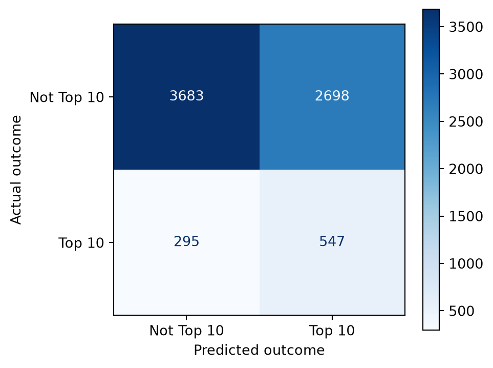

```python
fig, ax = plt.subplots(figsize=(5, 4))
ConfusionMatrixDisplay.from_estimator(
    search.best_estimator_, X_test, y_test,
    display_labels=["Not Top 10", "Top 10"],
    cmap="Blues", ax=ax,
)
ax.set_xlabel("Predicted outcome")
ax.set_ylabel("Actual outcome")
plt.tight_layout()
plt.show()
```

*Figure 3: Confusion matrix of the tuned logistic regression on the test set.*

The code above was reviewed and designed by Claude. Anthropic. (2026). Claude (Opus 5.5 version) [Large language model]. https://claude.ai

### Modelling Results

Table 1 shows the cross-validation results. The baseline has a high accuracy (0.877) but an F1 score of 0, because it never predicts a Top 10 song. The tuned logistic regression (C = 0.1, balanced class weights) reached an F1 score of 0.277. It found about 65% of Top 10 songs (recall of 0.648), but only about 18% of its predicted hits were correct (precision of 0.176).

On the test set (Table 3), the tuned logistic regression reached an F1 score of 0.268, with a recall of 0.65 and a precision of 0.169. These scores are very close to the cross-validation scores in Table 1 (F1 of 0.277), which suggests the cross-validation results were a reliable estimate of how the model performs on new songs. The confusion matrix in Figure 3 shows the same pattern: the model correctly identifies most of the songs that reached the Top 10, but it also predicts many songs as hits that did not make it, which is why its precision is low.

Overall, the model does better than the baseline, but the audio features, genre and era only give a weak signal for predicting Top 10 hits.

The text above was drafted with help from Claude. Anthropic. (2026). Claude (Opus 5.5 version) [Large language model]. https://claude.ai

### Discussion

Our results suggest that a song’s audio features, genre and release era can predict whether it reaches the Top 10 only to a limited extent. The tuned logistic regression identified about two thirds of Top 10 songs on the test set, but most songs it predicted as hits did not actually reach the Top 10 so it would not be reliable enough for record labels or streaming services to base investment decisions on. These findings are in line with our exploratory data analysis, which showed only small differences in audio features between Top 10 and non-Top 10 songs. Our analysis is also limited by the small share of Top 10 songs (about 12%), the use of the peak chart year as an approximation of release era, the use of only one genre per song, and a single train/test split.

Based on these results, future models could include additional information that is not captured by a song’s sound, such as marketing and promotion data and the artist’s existing popularity (for example, their previous chart success). Future work could also test whether models that capture interactions between features, such as a random forest, lead to better predictions.

## References

Castillo, Jaime Ramírez, M. Julia Flores, and Philippe Leray. 2024. “Predicting Spotify Audio Features from Last.fm Tags.” *Multimedia Tools and Applications* 83 (16): 48311–48330. https://doi.org/10.1007/s11042-023-17160-5.

He, Haibo, and Edwardo A. Garcia. 2009. “Learning from Imbalanced Data.” *IEEE Transactions on Knowledge and Data Engineering* 21 (9): 1263–1284. https://doi.org/10.1109/TKDE.2008.239.

Miller, Sean. 2023. “Billboard Hot 100 Weekly Charts with Spotify Audio Features.” data.world. https://data.world/kcmillersean.

The Devastator. 2023. “Billboard Hot Weekly Charts: Billboard Hot 100 Weekly Charts with Spotify Audio Features.” Kaggle. https://www.kaggle.com/datasets/thedevastator/billboard-hot-100-audio-features.